# Cancer Predisposition Sequencing Report - SEQC-II-50pc__SEQC-II_Tumor_50pc-normal

June 14, 2020

## Settings

The report is generated with *cpsr* version 0.5.2.6, ( *pcgr* version 0.8.4.10), using the following key settings:

- Genome assembly: **grch38**
- Report theme (Bootstrap): **default**
- Control population gnomAD: **Global non-cancer subset**
- Upper MAF threshold (gnomAD) for unclassified variants included in report: **0.05**
- Show GWAS hits in report: **TRUE**
  - Minimum p-value for association: **0**
- Cancer predisposition geneset (virtual gene panel):
  - **Custom gene panel**
  - User-defined panel (BED)

## Summary of findings

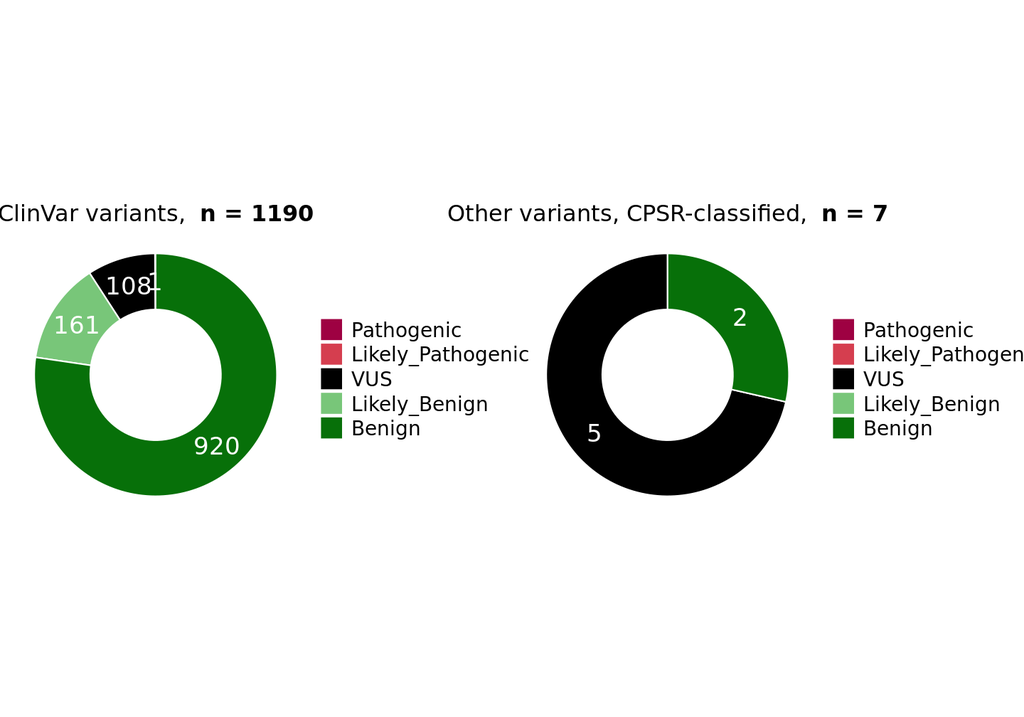

## Germline SNVs/InDels

### Variant statistics

Variant numbers in the selected cancer predisposition genes (n = 215)

- Number of SNVs: **19010**
- Number of InDels: **4550**
- Number of protein-coding variants: **114**

### Class 5 - **Pathogenic** variants

- A total of n = **1** variants are registered with a *Pathogenic* clinical significance in ClinVar.
- A total of n = **0** **non-ClinVar** variants (i.e. not registered in ClinVar) are classified with a *Pathogenic* significance by CPSR (ACMG criteria - based on population frequency and variant effect).

#### ClinVar

Consequence

Genotype

heterozygous

Gene

ClinVar phenotype(s)

ClinVar review status stars

ClinVar conflicting interpretations

MAF gnomAD (Global non-cancer subset)

|  | SYMBOL | SOURCE | CLINVAR_PHENOTYPE | CONSEQUENCE | PROTEIN_CHANGE | GENOTYPE | GENE_NAME | PROTEIN_DOMAIN | HGVSp | HGVSc | NCBI_REFSEQ | CDS_CHANGE | REFSEQ_MRNA | MUTATION_HOTSPOT | RMSK_HIT | PROTEIN_FEATURE | PREDICTED_EFFECT | LOSS_OF_FUNCTION | DBSNP | CLINVAR | CLINVAR_CLASSIFICATION | CLINVAR_REVIEW_STATUS_STARS | CLINVAR_CONFLICTED | CLINVAR_VARIANT_ORIGIN | ONCOGENE | TUMOR_SUPPRESSOR | GLOBAL_AF_GNOMAD | NON_CANCER_AF_GLOBAL | GENOMIC_CHANGE | … |
| --- | --- | --- | --- | --- | --- | --- | --- | --- | --- | --- | --- | --- | --- | --- | --- | --- | --- | --- | --- | --- | --- | --- | --- | --- | --- | --- | --- | --- | --- | --- |
| 1 | BRCA1 | ClinVar | Familial cancer of breast; Hereditary cancer-predisposing syndrome; Hereditary breast and ovarian cancer syndrome; Neoplasm of the breast; Breast-ovarian cancer, familial 1; Pancreatic cancer 4; FANCO… | stop_gained | p.Arg1772Ter | heterozygous | BRCA1 DNA repair associated |  | ENSP00000418960.2:p.Arg1772Ter | ENST00000471181.7:c.5314C>T | NM_007300 | stop_gained:ENST00000471181.7:c.5314C>T:exon20:p.R1772X | NM_007300 |  |  |  | SIFT:NA, SIFT4G:NA, LRT:tolerated, MutationTaster:damaging, MutationAssessor:NA, FATHMM:NA, FATHMM-mkl:damaging, PROVEAN:NA, M-CAP:NA, MutPred:NA, Ensembl-SVM:NA, Ensembl-LogisticRegression:NA, GERP++… | True | rs80357123 | Germline - Hereditary breast and ovarian cancer syndrome;not provided;Breast-ovarian cancer, familial 1;Hereditary cancer-predisposing syndrome;Neoplasm of the breast;Familial cancer of breast;Pancrea… | Pathogenic | 3 | False | germline | False | True | 1.19e-05 | 8.4e-06 | 17:g.43057078G>A | … |

#### Non-ClinVar

### Class 4 - **Likely Pathogenic** variants

- A total of n = **0** variants are recorded with a *Likely Pathogenic* clinical significance in ClinVar.
- A total of n = **0** **non-ClinVar** variants (i.e. not registered in ClinVar) are classified with a *Likely Pathogenic* significance by CPSR (ACMG criteria - based on population frequency and variant effect).

#### ClinVar

#### Non-Clinvar

### Class 3 - **Variants of Uncertain Significance (VUS)**

- A total of n = **108** variants are recorded with a *VUS* clinical significance in ClinVar.
- A total of n = **5** **non-ClinVar** variants (i.e. not registered in ClinVar) are classified with a *VUS* significance by CPSR (ACMG criteria - based on population frequency and variant effect).

#### ClinVar

Consequence

Genotype

heterozygous

homozygous

Gene

ClinVar phenotype(s)

ClinVar review status stars

ClinVar conflicting interpretations

MAF gnomAD (Global non-cancer subset)

|  | SYMBOL | SOURCE | CLINVAR_PHENOTYPE | CONSEQUENCE | PROTEIN_CHANGE | GENOTYPE | GENE_NAME | PROTEIN_DOMAIN | HGVSp | HGVSc | NCBI_REFSEQ | CDS_CHANGE | REFSEQ_MRNA | MUTATION_HOTSPOT | RMSK_HIT | PROTEIN_FEATURE | PREDICTED_EFFECT | LOSS_OF_FUNCTION | DBSNP | CLINVAR | CLINVAR_CLASSIFICATION | CLINVAR_REVIEW_STATUS_STARS | CLINVAR_CONFLICTED | CLINVAR_VARIANT_ORIGIN | ONCOGENE | TUMOR_SUPPRESSOR | GLOBAL_AF_GNOMAD | NON_CANCER_AF_GLOBAL | GENOMIC_CHANGE | … |
| --- | --- | --- | --- | --- | --- | --- | --- | --- | --- | --- | --- | --- | --- | --- | --- | --- | --- | --- | --- | --- | --- | --- | --- | --- | --- | --- | --- | --- | --- | --- |
| 1 | FH | ClinVar | Fumarase deficiency; Multiple cutaneous leiomyomas; not specified; Multiple Cutaneous and Uterine Leiomyomas | intron_variant |  | heterozygous | fumarate hydratase |  |  | ENST00000366560.3:c.1237-16_1237-13dup | NM_000143 |  | NM_000143 |  |  |  |  | False | rs144131869 | Germline - Fumarase deficiency;Multiple Cutaneous and Uterine Leiomyomas;Multiple cutaneous leiomyomas;not specified | VUS | 2 | False | germline | False | True | 0 | 0 | 1:g.241500602T>TGAGA | … |
| 2 | FH | ClinVar | Fumarase deficiency; Multiple cutaneous leiomyomas; Multiple Cutaneous and Uterine Leiomyomas | intron_variant |  | heterozygous | fumarate hydratase |  |  | ENST00000366560.3:c.1237-18_1237-13dup | NM_000143 |  | NM_000143 |  |  |  |  | False | rs144131869 | Germline - Multiple Cutaneous and Uterine Leiomyomas;Fumarase deficiency;Multiple cutaneous leiomyomas | VUS | 1 | False | germline | False | True | 0 | 0 | 1:g.241500602T>TGAGAGA | … |
| 3 | APC | ClinVar | Familial colorectal cancer | intron_variant |  | heterozygous | APC regulator of WNT signaling pathway |  |  | ENST00000508376.6:c.-19+199C>T | NM_001127510, NM_001354898, NM_001354904 |  | NM_001127510, NM_001354898, NM_001354904 |  |  |  |  | False | rs2020383 | Germline - Familial colorectal cancer | VUS | 0 | False | germline | False | True | 0 | 0 | 5:g.112738659C>T | … |
| 4 | APC | ClinVar | Familial colorectal cancer | intron_variant |  | heterozygous | APC regulator of WNT signaling pathway |  |  | ENST00000508376.6:c.-19+1790T>C | NM_001127510, NM_001354898, NM_001354904 |  | NM_001127510, NM_001354898, NM_001354904 |  |  |  |  | False | rs74627407 | Germline - Familial colorectal cancer | VUS | 0 | False | germline | False | True | 0 | 0 | 5:g.112740250T>C | … |
| 5 | APC | ClinVar | Familial colorectal cancer | intron_variant |  | heterozygous | APC regulator of WNT signaling pathway |  |  | ENST00000508376.6:c.-19+3524C>T | NM_001127510, NM_001354898, NM_001354904 |  | NM_001127510, NM_001354898, NM_001354904 |  | L1MB3\|LINE\|L1 |  |  | False | rs7706623 | Germline - Familial colorectal cancer | VUS | 0 | False | germline | False | True | 0 | 0 | 5:g.112741984C>T | … |
| 6 | APC | ClinVar | Familial colorectal cancer | intron_variant |  | heterozygous | APC regulator of WNT signaling pathway |  |  | ENST00000508376.6:c.-19+3613A>G | NM_001127510, NM_001354898, NM_001354904 |  | NM_001127510, NM_001354898, NM_001354904 |  | L1MB3\|LINE\|L1 |  |  | False | rs4705609 | Germline - Familial colorectal cancer | VUS | 0 | False | germline | False | True | 0 | 0 | 5:g.112742073A>G | … |
| 7 | APC | ClinVar | Familial colorectal cancer | intron_variant |  | heterozygous | APC regulator of WNT signaling pathway |  |  | ENST00000508376.6:c.-19+6571G>A | NM_001127510, NM_001354898, NM_001354904 |  | NM_001127510, NM_001354898, NM_001354904 |  | MIRb\|SINE\|MIR |  |  | False | rs464002 | Germline - Familial colorectal cancer | VUS | 0 | False | germline | False | True | 0 | 0 | 5:g.112745031G>A | … |
| 8 | APC | ClinVar | Familial colorectal cancer | intron_variant |  | heterozygous | APC regulator of WNT signaling pathway |  |  | ENST00000508376.6:c.-18-5070A>G | NM_001127510, NM_001354898, NM_001354904 |  | NM_001127510, NM_001354898, NM_001354904 |  | L1M5\|LINE\|L1 |  |  | False | rs75848865 | Germline - Familial colorectal cancer | VUS | 0 | False | germline | False | True | 0 | 0 | 5:g.112749803A>G | … |
| 9 | APC | ClinVar | Familial colorectal cancer | intron_variant |  | heterozygous | APC regulator of WNT signaling pathway |  |  | ENST00000508376.6:c.-18-3696C>T | NM_001127510, NM_001354898, NM_001354904 |  | NM_001127510, NM_001354898, NM_001354904 |  | L1MC4a\|LINE\|L1 |  |  | False | rs11950612 | Germline - Familial colorectal cancer | VUS | 0 | False | germline | False | True | 0 | 0 | 5:g.112751177C>T | … |
| 10 | APC | ClinVar | Familial colorectal cancer | intron_variant |  | heterozygous | APC regulator of WNT signaling pathway |  |  | ENST00000508376.6:c.-18-3243T>G | NM_001127510, NM_001354898, NM_001354904 |  | NM_001127510, NM_001354898, NM_001354904 |  | L1M5\|LINE\|L1 |  |  | False | rs11954856 | Germline - Familial colorectal cancer | VUS | 0 | False | germline | False | True | 0 | 0 | 5:g.112751630T>G | … |

[output cut: 98 more lines]

#### Non-Clinvar

Consequence

Genotype

heterozygous

Gene

CPSR classification (ACMG criteria codes)

CPSR pathogenicity score

MAF gnomAD (Global non-cancer subset)

|  | SYMBOL | SOURCE | CONSEQUENCE | PROTEIN_CHANGE | GENOTYPE | GENE_NAME | PROTEIN_DOMAIN | HGVSp | HGVSc | NCBI_REFSEQ | CDS_CHANGE | REFSEQ_MRNA | MUTATION_HOTSPOT | RMSK_HIT | PROTEIN_FEATURE | PREDICTED_EFFECT | LOSS_OF_FUNCTION | DBSNP | CPSR_CLASSIFICATION | CPSR_CLASSIFICATION_SCORE | CPSR_CLASSIFICATION_DOC | CPSR_CLASSIFICATION_CODE | ONCOGENE | TUMOR_SUPPRESSOR | GLOBAL_AF_GNOMAD | NON_CANCER_AF_GLOBAL | GENOMIC_CHANGE | GENOME_VERSION |
| --- | --- | --- | --- | --- | --- | --- | --- | --- | --- | --- | --- | --- | --- | --- | --- | --- | --- | --- | --- | --- | --- | --- | --- | --- | --- | --- | --- | --- |
| 1 | MSH3 | Other | missense_variant | p.Glu7Gly | heterozygous | mutS homolog 3 |  | ENSP00000499617.1:p.Glu7Gly | ENST00000658259.1:c.20A>G |  | missense_variant:ENST00000658259.1:c.20A>G:exon1:p.E7G |  |  | MIR3\|SINE\|MIR |  |  | False | rs6151599 | VUS | 1.5 | - Alternate allele absent in the population-specific non-cancer gnomAD subset- Missense variant in a gene that has a relatively low rate of benign missense variation (50% of high-confidence pathogenic… | ACMG_PM2_2\|ACMG_PP2 | False | False | 0 | 0 | 5:g.80655213A>G | grch38 |
| 2 | TSHR | Other | missense_variant | p.Glu76Lys | heterozygous | thyroid stimulating hormone receptor |  | ENSP00000495625.1:p.Glu76Lys | ENST00000642209.1:c.226G>A |  | missense_variant:ENST00000642209.1:c.226G>A:exon2:p.E76K |  |  |  |  | SIFT:NA, SIFT4G:NA, LRT:NA, MutationTaster:possibly_damaging, MutationAssessor:NA, FATHMM:NA, FATHMM-mkl:tolerated, PROVEAN:NA, M-CAP:NA, MutPred:NA, Ensembl-SVM:NA, Ensembl-LogisticRegression:NA, GER… | False | rs724170 | VUS | 1.5 | - Alternate allele absent in the population-specific non-cancer gnomAD subset- Missense variant in a gene that has a relatively low rate of benign missense variation (50% of high-confidence pathogenic… | ACMG_PM2_2\|ACMG_PP2 | False | False | 0 | 0 | 14:g.80991596G>A | grch38 |
| 3 | AR | Other | inframe_deletion | p.Gln80del | heterozygous | androgen receptor |  | ENSP00000363822.3:p.Gln80del | ENST00000374690.9:c.237_239del | NM_000044 | inframe_deletion:ENST00000374690.9:c.237_239del:exon1:p.Q80del | NM_000044 |  | (GCA)n\|Simple_repeat\|Simple_repeat |  |  | False | rs3032358 | VUS | 1 | - Alternate allele absent in the population-specific non-cancer gnomAD subset | ACMG_PM2_2 | True | True | 0 | 0 | X:g.67545316TGCA>T | grch38 |
| 4 | JMJD1C | Other | missense_variant | p.Gly1413Asp | heterozygous | jumonji domain containing 1C |  | ENSP00000382204.2:p.Gly1413Asp | ENST00000399262.7:c.4238G>A | NM_001322252, NM_032776 | missense_variant:ENST00000399262.7:c.4238G>A:exon10:p.G1413D | NM_001322252, NM_032776 |  |  |  | SIFT:damaging, SIFT4G:tolerated, LRT:tolerated, MutationTaster:tolerated, MutationAssessor:tolerated, FATHMM:tolerated, FATHMM-mkl:tolerated, PROVEAN:tolerated, M-CAP:tolerated, MutPred:0.07, Ensembl-… | False |  | VUS | 0.5 | - Alternate allele absent in the population-specific non-cancer gnomAD subset- Missense variant in a gene that has a relatively low rate of benign missense variation (50% of high-confidence pathogenic… | ACMG_PM2_2\|ACMG_PP2\|ACMG_BP4 | False | False | 0 | 0 | 10:g.63207431C>T | grch38 |
| 5 | MLH3 | Other | missense_variant | p.Ile609Leu | heterozygous | mutL homolog 3 |  | ENSP00000452316.1:p.Ile609Leu | ENST00000556740.5:c.1825A>C |  | missense_variant:ENST00000556740.5:c.1825A>C:exon1:p.I609L |  |  |  |  | SIFT:tolerated, SIFT4G:tolerated, LRT:damaging, MutationTaster:tolerated, MutationAssessor:damaging, FATHMM:tolerated, FATHMM-mkl:damaging, PROVEAN:tolerated, M-CAP:tolerated, MutPred:0.365, Ensembl-S… | False | rs61755654 | VUS | -0.5 | - Allele count within pathogenic range (MAF - Multiple lines (>=5) of computational evidence support a benign effect on the gene or gene product (conservation, evolutionary, splicing impact, etc. - fr… | ACMG_PM2_1\|ACMG_BP4 | False | False | 8e-06 | 8.5e-06 | 14:g.75047831T>G | grch38 |

### Class 2 - **Likely Benign** variants

- A total of n = **161** variants are recorded with a *Likely Benign* clinical significance in ClinVar.
- A total of n = **0** **Other** variants (i.e. not registered in ClinVar) are classified with a *Likely Benign* significance by CPSR (ACMG criteria - based on population frequency and variant effect).

#### ClinVar

Consequence

Genotype

heterozygous

homozygous

Gene

ClinVar phenotype(s)

ClinVar review status stars

ClinVar conflicting interpretations

MAF gnomAD (Global non-cancer subset)

|  | SYMBOL | SOURCE | CLINVAR_PHENOTYPE | CONSEQUENCE | PROTEIN_CHANGE | GENOTYPE | GENE_NAME | PROTEIN_DOMAIN | HGVSp | HGVSc | NCBI_REFSEQ | CDS_CHANGE | REFSEQ_MRNA | MUTATION_HOTSPOT | RMSK_HIT | PROTEIN_FEATURE | PREDICTED_EFFECT | LOSS_OF_FUNCTION | DBSNP | CLINVAR | CLINVAR_CLASSIFICATION | CLINVAR_REVIEW_STATUS_STARS | CLINVAR_CONFLICTED | CLINVAR_VARIANT_ORIGIN | ONCOGENE | TUMOR_SUPPRESSOR | GLOBAL_AF_GNOMAD | NON_CANCER_AF_GLOBAL | GENOMIC_CHANGE | … |
| --- | --- | --- | --- | --- | --- | --- | --- | --- | --- | --- | --- | --- | --- | --- | --- | --- | --- | --- | --- | --- | --- | --- | --- | --- | --- | --- | --- | --- | --- | --- |
| 1 | NRAS | ClinVar | Noonan syndrome | 3_prime_UTR_variant |  | heterozygous | NRAS proto-oncogene, GTPase |  |  | ENST00000369535.5:c.*2965del | NM_002524 |  | NM_002524 |  |  |  |  | False | rs61652108 | Germline - Noonan syndrome | Likely_Benign | 1 | False | germline | True | False | 0 | 0 | 1:g.114705128TA>T | … |
| 2 | NRAS | ClinVar | Noonan syndrome | 3_prime_UTR_variant |  | heterozygous | NRAS proto-oncogene, GTPase |  |  | ENST00000369535.5:c.*872C>T | NM_002524 |  | NM_002524 |  |  |  |  | False | rs14804 | Germline - Noonan syndrome | Likely_Benign | 1 | False | germline | True | False | 0 | 0 | 1:g.114707222G>A | … |
| 3 | ALK | ClinVar | Neuroblastoma Susceptibility | 3_prime_UTR_variant |  | heterozygous | ALK receptor tyrosine kinase |  |  | ENST00000389048.8:c.*63A>G | NM_004304 |  | NM_004304 |  |  |  |  | False | rs182561050 | Germline - Neuroblastoma Susceptibility | Likely_Benign | 1 | False | germline | True | False | 0 | 0 | 2:g.29193161T>C | … |
| 4 | ALK | ClinVar | Hereditary cancer-predisposing syndrome; Neuroblastoma 3; not specified; Neuroblastoma Susceptibility | synonymous_variant | p.Tyr1401= | heterozygous | ALK receptor tyrosine kinase |  | ENSP00000373700.3:p.Tyr1401= | ENST00000389048.8:c.4203T>C | NM_004304 | synonymous_variant:ENST00000389048.8:c.4203T>C:exon29:p.Y1401Y | NM_004304 |  |  |  |  | False | rs55772745 | Germline - Neuroblastoma 3;Neuroblastoma Susceptibility;Hereditary cancer-predisposing syndrome;not specified | Likely_Benign | 2 | False | germline | True | False | 0.004438 | 0.0043321 | 2:g.29193884A>G | … |
| 5 | ALK | ClinVar | Hereditary cancer-predisposing syndrome; Neuroblastoma 3; not specified; Neuroblastoma Susceptibility; not provided | synonymous_variant | p.Ser1136= | heterozygous | ALK receptor tyrosine kinase |  | ENSP00000373700.3:p.Ser1136= | ENST00000389048.8:c.3408C>T | NM_004304 | synonymous_variant:ENST00000389048.8:c.3408C>T:exon21:p.S1136S | NM_004304 |  |  |  |  | False | rs56146053 | Germline - Neuroblastoma Susceptibility;not specified;Neuroblastoma 3;Hereditary cancer-predisposing syndrome;not provided | Likely_Benign | 2 | False | germline | True | False | 0.006712 | 0.0065829 | 2:g.29222559G>A | … |
| 6 | SOS1 | ClinVar | Gingival fibromatosis; Noonan syndrome | 3_prime_UTR_variant |  | homozygous | SOS Ras/Rac guanine nucleotide exchange factor 1 |  |  | ENST00000402219.6:c.*3918T>C | NM_005633 |  | NM_005633 |  |  |  |  | False | rs1043793 | Germline - Gingival fibromatosis;Noonan syndrome | Likely_Benign | 1 | False | germline | False | False | 0 | 0 | 2:g.38981906A>G | … |
| 7 | SOS1 | ClinVar | Gingival fibromatosis; Noonan syndrome | 3_prime_UTR_variant |  | homozygous | SOS Ras/Rac guanine nucleotide exchange factor 1 |  |  | ENST00000402219.6:c.*3539T>C | NM_005633 |  | NM_005633 |  |  |  |  | False | rs1037495 | Germline - Gingival fibromatosis;Noonan syndrome | Likely_Benign | 1 | False | germline | False | False | 0 | 0 | 2:g.38982285A>G | … |
| 8 | SOS1 | ClinVar | Gingival fibromatosis; Noonan syndrome | 3_prime_UTR_variant |  | homozygous | SOS Ras/Rac guanine nucleotide exchange factor 1 |  |  | ENST00000402219.6:c.*2567T>A | NM_005633 |  | NM_005633 |  |  |  |  | False | rs6704656 | Germline - Noonan syndrome;Gingival fibromatosis | Likely_Benign | 1 | False | germline | False | False | 0 | 0 | 2:g.38983257A>T | … |
| 9 | SOS1 | ClinVar | Gingival fibromatosis; Noonan syndrome; not specified | 3_prime_UTR_variant |  | homozygous | SOS Ras/Rac guanine nucleotide exchange factor 1 |  |  | ENST00000402219.6:c.*2244_*2245dup | NM_005633 |  | NM_005633 |  |  |  |  | False | rs3832123 | Germline - not specified;Noonan syndrome;Gingival fibromatosis | Likely_Benign | 2 | False | germline | False | False | 0 | 0 | 2:g.38983578T>TTA | … |
| 10 | SOS1 | ClinVar | Gingival fibromatosis; Noonan syndrome | 3_prime_UTR_variant |  | homozygous | SOS Ras/Rac guanine nucleotide exchange factor 1 |  |  | ENST00000402219.6:c.*1844A>G | NM_005633 |  | NM_005633 |  |  |  |  | False | rs10166395 | Germline - Gingival fibromatosis;Noonan syndrome | Likely_Benign | 1 | False | germline | False | False | 0 | 0 | 2:g.38983980T>C | … |

[output cut: 151 more lines]

#### Non-Clinvar

### Class 1 - **Benign** variants

- A total of n = **920** variants are recorded with a *Benign* clinical significance in ClinVar.
- A total of n = **2** **Other** variants (i.e. not registered in ClinVar) are classified with a *Benign* significance by CPSR (ACMG criteria - based on population frequency and variant effect).

#### ClinVar

Consequence

Genotype

heterozygous

homozygous

Gene

ClinVar phenotype(s)

ClinVar review status stars

ClinVar conflicting interpretations

MAF gnomAD (Global non-cancer subset)

|  | SYMBOL | SOURCE | CLINVAR_PHENOTYPE | CONSEQUENCE | PROTEIN_CHANGE | GENOTYPE | GENE_NAME | PROTEIN_DOMAIN | HGVSp | HGVSc | NCBI_REFSEQ | CDS_CHANGE | REFSEQ_MRNA | MUTATION_HOTSPOT | RMSK_HIT | PROTEIN_FEATURE | PREDICTED_EFFECT | LOSS_OF_FUNCTION | DBSNP | CLINVAR | CLINVAR_CLASSIFICATION | CLINVAR_REVIEW_STATUS_STARS | CLINVAR_CONFLICTED | CLINVAR_VARIANT_ORIGIN | ONCOGENE | TUMOR_SUPPRESSOR | GLOBAL_AF_GNOMAD | NON_CANCER_AF_GLOBAL | GENOMIC_CHANGE | … |
| --- | --- | --- | --- | --- | --- | --- | --- | --- | --- | --- | --- | --- | --- | --- | --- | --- | --- | --- | --- | --- | --- | --- | --- | --- | --- | --- | --- | --- | --- | --- |
| 1 | KIF1B | ClinVar | Pheochromocytoma; Charcot-Marie-Tooth disease, type 2; Neuroblastoma | 3_prime_UTR_variant |  | heterozygous | kinesin family member 1B |  |  | ENST00000377086.5:c.*279_*280del | NM_001365951, NM_001365952 |  | NM_001365951, NM_001365952 |  | (AC)n\|Simple_repeat\|Simple_repeat |  |  | False | rs111663673 | Germline - Neuroblastoma;Charcot-Marie-Tooth disease, type 2;Pheochromocytoma | Benign | 1 | False | germline | False | False | 0 | 0 | 1:g.10376834AAC>A | … |
| 2 | SDHB | ClinVar | Hereditary cancer-predisposing syndrome; Pheochromocytoma; Paraganglioma and gastric stromal sarcoma; not specified; not provided | synonymous_variant | p.Ala6= | homozygous | succinate dehydrogenase complex iron sulfur subunit B |  | ENSP00000364649.3:p.Ala6= | ENST00000375499.7:c.18C>A | NM_003000 | synonymous_variant:ENST00000375499.7:c.18C>A:exon1:p.A6A | NM_003000 |  |  | TRANSIT:Mitochondrion:1-28 |  | False | rs2746462 | Germline - not specified;Hereditary cancer-predisposing syndrome;Paraganglioma and gastric stromal sarcoma;Pheochromocytoma;not provided | Benign | 2 | False | germline | False | True | 0.9737 | 0.973942 | 1:g.17054002G>T | … |
| 3 | ALK | ClinVar | Neuroblastoma Susceptibility | 3_prime_UTR_variant |  | homozygous | ALK receptor tyrosine kinase |  |  | ENST00000389048.8:c.*298C>T | NM_004304 |  | NM_004304 |  |  |  |  | False | rs1728828 | Germline - Neuroblastoma Susceptibility | Benign | 1 | False | germline | True | False | 0 | 0 | 2:g.29192926G>A | … |
| 4 | ALK | ClinVar | Hereditary cancer-predisposing syndrome; Neuroblastoma 3; not specified; Neuroblastoma Susceptibility; not provided | missense_variant | p.Lys1491Arg | heterozygous | ALK receptor tyrosine kinase |  | ENSP00000373700.3:p.Lys1491Arg | ENST00000389048.8:c.4472A>G | NM_004304 | missense_variant:ENST00000389048.8:c.4472A>G:exon29:p.K1491R | NM_004304 |  |  |  | SIFT:tolerated, SIFT4G:tolerated, LRT:NA, MutationTaster:possibly_damaging, MutationAssessor:tolerated, FATHMM:tolerated, FATHMM-mkl:damaging, PROVEAN:tolerated, M-CAP:NA, MutPred:NA, Ensembl-SVM:tole… | False | rs1881420 | Germline - not specified;Neuroblastoma Susceptibility;Hereditary cancer-predisposing syndrome;not provided;Neuroblastoma 3 | Benign | 2 | False | germline | True | False | 0.3437 | 0.349007 | 2:g.29193615T>C | … |
| 5 | ALK | ClinVar | Hereditary cancer-predisposing syndrome; Neuroblastoma 3; not specified; Neuroblastoma Susceptibility; not provided | missense_variant | p.Ile1461Val | homozygous | ALK receptor tyrosine kinase |  | ENSP00000373700.3:p.Ile1461Val | ENST00000389048.8:c.4381A>G | NM_004304 | missense_variant:ENST00000389048.8:c.4381A>G:exon29:p.I1461V | NM_004304 |  |  |  | SIFT:tolerated, SIFT4G:tolerated, LRT:tolerated, MutationTaster:possibly_damaging, MutationAssessor:tolerated, FATHMM:tolerated, FATHMM-mkl:tolerated, PROVEAN:tolerated, M-CAP:NA, MutPred:NA, Ensembl-… | False | rs1670283 | Germline - not specified;Neuroblastoma Susceptibility;Hereditary cancer-predisposing syndrome;not provided;Neuroblastoma 3 | Benign | 2 | False | germline | True | False | 0.9976 | 0.997594 | 2:g.29193706T>C | … |
| 6 | ALK | ClinVar | Hereditary cancer-predisposing syndrome; Neuroblastoma 3; not specified; Neuroblastoma Susceptibility; not provided | synonymous_variant | p.Gly1125= | heterozygous | ALK receptor tyrosine kinase |  | ENSP00000373700.3:p.Gly1125= | ENST00000389048.8:c.3375C>A | NM_004304 | synonymous_variant:ENST00000389048.8:c.3375C>A:exon21:p.G1125G | NM_004304 |  |  |  |  | False | rs3795850 | Germline - Neuroblastoma Susceptibility;not specified;Hereditary cancer-predisposing syndrome;not provided;Neuroblastoma 3 | Benign | 2 | False | germline | True | False | 0.3369 | 0.342332 | 2:g.29222592G>T | … |
| 7 | ALK | ClinVar | Hereditary cancer-predisposing syndrome; not specified; Neuroblastoma Susceptibility; not provided | synonymous_variant | p.Thr1012= | heterozygous | ALK receptor tyrosine kinase |  | ENSP00000373700.3:p.Thr1012= | ENST00000389048.8:c.3036G>A | NM_004304 | synonymous_variant:ENST00000389048.8:c.3036G>A:exon18:p.T1012T | NM_004304 |  |  |  |  | False | rs2293563 | Germline - not specified;Neuroblastoma Susceptibility;Hereditary cancer-predisposing syndrome;not provided | Benign | 2 | False | germline | True | False | 0.1562 | 0.155035 | 2:g.29226953C>T | … |
| 8 | ALK | ClinVar | Hereditary cancer-predisposing syndrome; Neuroblastoma 3; not specified; Neuroblastoma Susceptibility; not provided | synonymous_variant | p.Gly845= | heterozygous | ALK receptor tyrosine kinase |  | ENSP00000373700.3:p.Gly845= | ENST00000389048.8:c.2535T>C | NM_004304 | synonymous_variant:ENST00000389048.8:c.2535T>C:exon15:p.G845G | NM_004304 |  |  |  |  | False | rs2256740 | Germline - not specified;Neuroblastoma Susceptibility;Hereditary cancer-predisposing syndrome;not provided;Neuroblastoma 3 | Benign | 2 | False | germline | True | False | 0.6073 | 0.603737 | 2:g.29232401A>G | … |
| 9 | ALK | ClinVar | Hereditary cancer-predisposing syndrome; Neuroblastoma 3; not specified; Neuroblastoma Susceptibility; not provided | synonymous_variant | p.Gln500= | heterozygous | ALK receptor tyrosine kinase |  | ENSP00000373700.3:p.Gln500= | ENST00000389048.8:c.1500A>G | NM_004304 | synonymous_variant:ENST00000389048.8:c.1500A>G:exon7:p.Q500Q | NM_004304 |  |  |  |  | False | rs2293564 | Germline - not specified;Neuroblastoma Susceptibility;Hereditary cancer-predisposing syndrome;not provided;Neuroblastoma 3 | Benign | 2 | False | germline | True | False | 0.8777 | 0.877623 | 2:g.29320797T>C | … |
| 10 | ALK | ClinVar | Hereditary cancer-predisposing syndrome; Neuroblastoma 3; not specified; Neuroblastoma Susceptibility; not provided | synonymous_variant | p.Pro234= | heterozygous | ALK receptor tyrosine kinase |  | ENSP00000373700.3:p.Pro234= | ENST00000389048.8:c.702T>A | NM_004304 | synonymous_variant:ENST00000389048.8:c.702T>A:exon2:p.P234P | NM_004304 |  |  |  |  | False | rs2246745 | Germline - not specified;Neuroblastoma Susceptibility;Hereditary cancer-predisposing syndrome;not provided;Neuroblastoma 3 | Benign | 2 | False | germline | True | False | 0.7408 | 0.739596 | 2:g.29717663A>T | … |

[output cut: 910 more lines]

#### Non-Clinvar

Consequence

Genotype

heterozygous

Gene

CPSR classification (ACMG criteria codes)

CPSR pathogenicity score

MAF gnomAD (Global non-cancer subset)

|  | SYMBOL | SOURCE | CONSEQUENCE | PROTEIN_CHANGE | GENOTYPE | GENE_NAME | PROTEIN_DOMAIN | HGVSp | HGVSc | NCBI_REFSEQ | CDS_CHANGE | REFSEQ_MRNA | MUTATION_HOTSPOT | RMSK_HIT | PROTEIN_FEATURE | PREDICTED_EFFECT | LOSS_OF_FUNCTION | DBSNP | CPSR_CLASSIFICATION | CPSR_CLASSIFICATION_SCORE | CPSR_CLASSIFICATION_DOC | CPSR_CLASSIFICATION_CODE | ONCOGENE | TUMOR_SUPPRESSOR | GLOBAL_AF_GNOMAD | NON_CANCER_AF_GLOBAL | GENOMIC_CHANGE | GENOME_VERSION |
| --- | --- | --- | --- | --- | --- | --- | --- | --- | --- | --- | --- | --- | --- | --- | --- | --- | --- | --- | --- | --- | --- | --- | --- | --- | --- | --- | --- | --- |
| 1 | PTPN13 | Other | missense_variant | p.Arg2210Gln | heterozygous | protein tyrosine phosphatase non-receptor type 13 |  | ENSP00000426626.1:p.Arg2210Gln | ENST00000511467.1:c.6629G>A |  | missense_variant:ENST00000511467.1:c.6629G>A:exon42:p.R2210Q |  |  |  | MUTAGEN:R -> W: No effect on substrate affinity:2205-2205 | SIFT:tolerated, SIFT4G:tolerated, LRT:tolerated, MutationTaster:tolerated, MutationAssessor:tolerated, FATHMM:tolerated, FATHMM-mkl:damaging, PROVEAN:tolerated, M-CAP:NA, MutPred:NA, Ensembl-SVM:toler… | False | rs61750816 | Benign | -5.5 | - Very high MAF (> 1% in gnomAD non-cancer pop subset, min AN = 12,000) - recessive mode of inheritance- Missense variant in a gene that has a relatively low rate of benign missense variation (50% of … | ACMG_BA1_AR\|ACMG_PP2\|ACMG_BP4 | False | True | 0.01996 | 0.0196335 | 4:g.86803817G>A | grch38 |
| 2 | FAT1 | Other | missense_variant | p.Val129Leu | heterozygous | FAT atypical cadherin 1 |  | ENSP00000406229.2:p.Val129Leu | ENST00000441802.7:c.385G>C | NM_005245 | missense_variant:ENST00000441802.7:c.385G>C:exon2:p.V129L | NM_005245 |  |  | TOPO_DOM:Extracellular:22-4181 | SIFT:tolerated, SIFT4G:tolerated, LRT:tolerated, MutationTaster:tolerated, MutationAssessor:tolerated, FATHMM:tolerated, FATHMM-mkl:tolerated, PROVEAN:tolerated, M-CAP:NA, MutPred:NA, Ensembl-SVM:tole… | False | rs41278611 | Benign | -5.5 | - Very high MAF (> 1% in gnomAD non-cancer pop subset, min AN = 12,000) - recessive mode of inheritance- Missense variant in a gene that has a relatively low rate of benign missense variation (50% of … | ACMG_BA1_AR\|ACMG_PP2\|ACMG_BP4 | True | True | 0.03424 | 0.0342612 | 4:g.186709443C>G | grch38 |

### Genomic biomarkers

- Here, variants in the sample that overlap with reported clinical biomarkers from the [database for clinical interpretations of variants in cancer, CIViC](https://civic.genome.wustl.edu/#/home) are considered. Note that several variants in the query can overlap the same existing biomarker, given that biomarkers are reported at different resolutions (variant/gene level). Total number of clinical evidence items that coincide with query variants:
  - Predisposing: **1** evidence items
  - Predictive: **16** evidence items
  - Prognostic: **6** evidence items
  - Diagnostic: **0** evidence items

#### Predisposing

Cancer type

Clinical significance

Evidence level

Gene

Biomarker mapping

The table below lists all variant-evidence item associations:

|  | SYMBOL | GENE_NAME | CANCER_TYPE | CLINICAL_SIGNIFICANCE | EVIDENCE_LEVEL | RATING | EVIDENCE_DIRECTION | CITATION | THERAPEUTIC_CONTEXT | DESCRIPTION | BIOMARKER_MAPPING | CDS_CHANGE | GENOMIC_CHANGE |
| --- | --- | --- | --- | --- | --- | --- | --- | --- | --- | --- | --- | --- | --- |
| 1 | TP53 | tumor protein p53 | Breast Cancer | Positive | B: Clinical evidence | 4 | Does Not Support | Schmidt et al., 2007, Cancer Res. |  | Large meta-analysis of 5,191 breast cancer patients and 3,834 controls did not find a conclusive link between codon 72 allele and breast cancer susceptibility. Odds ratios were 0.98 (95% CI, 0.91–1.05… | exact | missense_variant:ENST00000269305.8:c.215C>G:exon4:p.P72R | 17:g.7676154G>C |

#### Predictive

Cancer type

Clinical significance

Evidence level

Gene

Biomarker mapping

Therapeutic context

The table below lists all variant-evidence item associations:

|  | SYMBOL | GENE_NAME | CANCER_TYPE | CLINICAL_SIGNIFICANCE | EVIDENCE_LEVEL | RATING | EVIDENCE_DIRECTION | CITATION | THERAPEUTIC_CONTEXT | DESCRIPTION | BIOMARKER_MAPPING | CDS_CHANGE | GENOMIC_CHANGE |
| --- | --- | --- | --- | --- | --- | --- | --- | --- | --- | --- | --- | --- | --- |
| 1 | BRCA1 | BRCA1 DNA repair associated | Cancer | Sensitivity/Response | A: Validated | 4 | Supports | Fong et al., 2009, N. Engl. J. Med. | Olaparib | In this phase 1 trial, 60 patients with advanced solid tumors (ovarian, breast, colorectal, melanoma, sarcoma, prostate) were treated with PARP inhibitor olaparib. Durable antitumor activity was only … | gene | stop_gained:ENST00000471181.7:c.5314C>T:exon20:p.R1772X | 17:g.43057078G>A |
| 2 | BRCA1 | BRCA1 DNA repair associated | Ovarian Carcinoma | Sensitivity/Response | B: Clinical evidence | 3 | Supports | Pennington et al., 2014, Clin. Cancer Res. | Platinum compound | In a study of ovarian carcinomas, 81% of tumors with germline BRCA1/2 mutations were platinum sensitive, whereas only 60% of tumors with non-BRCA1/2 mutations were platinum sensitive (N=47; N=158; P=0… | gene | stop_gained:ENST00000471181.7:c.5314C>T:exon20:p.R1772X | 17:g.43057078G>A |
| 3 | BRCA1 | BRCA1 DNA repair associated | Ovarian Cancer | Sensitivity/Response | B: Clinical evidence | 3 | Supports | Liu et al., 2014, Lancet Oncol. | Olaparib, Cediranib | 46 women with platinum-sensitive, high-grade, BRCA1/2+ ovarian cancer received either olaparib monotherapy or olaparib/cediranib combination therapy. Median PFS was increased in combination therapy (1… | gene | stop_gained:ENST00000471181.7:c.5314C>T:exon20:p.R1772X | 17:g.43057078G>A |
| 4 | BRCA1 | BRCA1 DNA repair associated | Triple-receptor Negative Breast Cancer | Sensitivity/Response | B: Clinical evidence | 3 | Supports | Isakoff et al., 2015, J. Clin. Oncol. | Cisplatin, Carboplatin | In an evaluation of 77 patients, those who had BRCA1/2 germline mutations (n=11) had an increase response rate to cisplatin when compared to those without germline mutations (54.5% versus 19.7%; P=0.0… | gene | stop_gained:ENST00000471181.7:c.5314C>T:exon20:p.R1772X | 17:g.43057078G>A |
| 5 | BRCA1 | BRCA1 DNA repair associated | Ovarian Cancer | Sensitivity/Response | B: Clinical evidence | 3 | Supports | Gelmon et al., 2011, Lancet Oncol. | Olaparib | In a study of 63 patients with ovarian cancer, 17 patients had BRCA1 or BRCA2 mutations and 46 patients had no BRCA mutations. Of the BRCA-positive patients, 7/17(41%; 95%CI 22-64) showed objective re… | gene | stop_gained:ENST00000471181.7:c.5314C>T:exon20:p.R1772X | 17:g.43057078G>A |
| 6 | BRCA1 | BRCA1 DNA repair associated | Triple-receptor Negative Breast Cancer | Resistance | B: Clinical evidence | 3 | Supports | Gelmon et al., 2011, Lancet Oncol. | Olaparib | In a study of 26 patients with breast cancer, 10 patients were BRCA-positive and 16 patients were BRCA-negative. Regardless of BRCA status, none showed objective response when treated with olaparib. | gene | stop_gained:ENST00000471181.7:c.5314C>T:exon20:p.R1772X | 17:g.43057078G>A |
| 7 | BRCA1 | BRCA1 DNA repair associated | Ovarian Cancer | Sensitivity/Response | B: Clinical evidence | 4 | Supports | Goff, 2013, J Gynecol Oncol | Olaparib | The combination of PARP inhibition (Olaparib) with BRCA mutation results in irreparable and lethal DNA damage. Response rates are higher in BRCA1 mutation positive women with high grade serous or undi… | gene | stop_gained:ENST00000471181.7:c.5314C>T:exon20:p.R1772X | 17:g.43057078G>A |
| 8 | BRCA1 | BRCA1 DNA repair associated | Breast Cancer | Sensitivity/Response | B: Clinical evidence | 4 | Supports | de Bono et al., 2017, Cancer Discov | Talazoparib | In part 2 of a two-part dose-escalation phase I trial (NCT01286987), 71 patients with Ewings sarcoma, breast, ovarian, small cell lung, or pancreatic cancers received 1.0 mg/day talazoparib treatment.… | gene | stop_gained:ENST00000471181.7:c.5314C>T:exon20:p.R1772X | 17:g.43057078G>A |
| 9 | BRCA1 | BRCA1 DNA repair associated | Ovarian Cancer | Sensitivity/Response | B: Clinical evidence | 3 | Supports | de Bono et al., 2017, Cancer Discov | Talazoparib | In part 2 of a two-part dose-escalation phase I trial (NCT01286987), 71 patients with Ewings sarcoma, breast, ovarian, small cell lung, or pancreatic cancers received 1.0 mg/day talazoparib treatment.… | gene | stop_gained:ENST00000471181.7:c.5314C>T:exon20:p.R1772X | 17:g.43057078G>A |
| 10 | BRCA1 | BRCA1 DNA repair associated | Her2-receptor Negative Breast Cancer | Sensitivity/Response | B: Clinical evidence | 5 | Supports | Robson et al., 2017, N. Engl. J. Med. | Olaparib | 302 patients (234 with progression events) with HER2-negative metastatic breast cancer and with a confirmed deleterious or suspected deleterious germline BRCA mutation (164 BRCA1, 129 BRCA2) had signi… | gene | stop_gained:ENST00000471181.7:c.5314C>T:exon20:p.R1772X | 17:g.43057078G>A |

[output cut: 6 more lines]

#### Prognostic

Gene

Cancer type

Clinical significance

Evidence level

Biomarker mapping

The table below lists all variant-evidence item associations:

|  | SYMBOL | GENE_NAME | CANCER_TYPE | CLINICAL_SIGNIFICANCE | EVIDENCE_LEVEL | RATING | EVIDENCE_DIRECTION | CITATION | THERAPEUTIC_CONTEXT | DESCRIPTION | BIOMARKER_MAPPING | CDS_CHANGE | GENOMIC_CHANGE |
| --- | --- | --- | --- | --- | --- | --- | --- | --- | --- | --- | --- | --- | --- |
| 1 | TP53 | tumor protein p53 | Cervical Cancer | Poor Outcome | B: Clinical evidence | 2 | Does Not Support | Klug et al., 2001, Cancer Epidemiol. Biomarkers Prev. |  | In a relatively small meta-analysis of 119 women with cervical cancer and 127 controls, associations with homozygosity for arginine, and heterozygosity at this locus were both associated with odds rat… | exact | missense_variant:ENST00000269305.8:c.215C>G:exon4:p.P72R | 17:g.7676154G>C |
| 2 | TP53 | tumor protein p53 | Lung Carcinoma | Poor Outcome | B: Clinical evidence | 3 | Does Not Support | Matakidou et al., 2003, Mutagenesis |  | Pooled data from 13 studies of patients with lung cancer found little effect of codon 72 allele on the overall survival of patients with lung cancer. Proline homozygous patients were correlated with s… | exact | missense_variant:ENST00000269305.8:c.215C>G:exon4:p.P72R | 17:g.7676154G>C |
| 3 | ERCC5 | ERCC excision repair 5, endonuclease | Parietal Lobe Ependymoma | Poor Outcome | B: Clinical evidence | 3 | Supports | Somers et al., 2015, Genes Dev. |  | The rs751402 polymorphism in the 5' UTR of ERCC5 was correlated with reduced progression free-survival in children with ependymoma that had been treated with platinum-based therapies. 55 post-operativ… | exact | NA | 13:g.102845848A>G |
| 4 | BRCA1 | BRCA1 DNA repair associated | Prostate Cancer | Poor Outcome | B: Clinical evidence | 3 | Supports | Castro et al., 2013, J. Clin. Oncol. |  | In a study of 2,019 patients with prostate cancer, 18 had germline BRCA1 mutations, 61 had germline BRCA2 mutations and 1,940 were non-carriers. Patients with BRCA1/2 mutations had a 2-fold higher inc… | gene | stop_gained:ENST00000471181.7:c.5314C>T:exon20:p.R1772X | 17:g.43057078G>A |
| 5 | BRCA1 | BRCA1 DNA repair associated | Ovarian Cancer | Better Outcome | B: Clinical evidence | 3 | Supports | Harter et al., 2016, Gynecol. Oncol. |  | 664 patients with non-bulky FIGO Stage II-IV ovarian cancer were evaluated for PFS when treated with Pazopanib versus placebo. Of the 664 patients, 10% (n=68) were BRCA1+, 4% were BRCA 2+ (n=29) and 8… | gene | stop_gained:ENST00000471181.7:c.5314C>T:exon20:p.R1772X | 17:g.43057078G>A |
| 6 | BRCA1 | BRCA1 DNA repair associated | Epithelial Ovarian Cancer | Better Outcome | B: Clinical evidence | 3 | Supports | Bolton et al., 2012, JAMA |  | In patients with invasive epithelial ovarian cancer, those with mutations in BRCA1 had better five-year overall survival. | gene | stop_gained:ENST00000471181.7:c.5314C>T:exon20:p.R1772X | 17:g.43057078G>A |

#### Diagnostic

*No variant-evidence item associations found.*

### **Secondary findings** (ACMG SF v2.0)

- A total of n = **0** variants in [genes recommended for incidental findings reporting](https://www.ncbi.nlm.nih.gov/clinvar/docs/acmg/) are registered with a *Pathogenic/Likely pathogenic* clinical significance in ClinVar.

|  | SYMBOL | CLIN_SIGNIFICANCE | CLINVAR_PHENOTYPE | CONSEQUENCE | PROTEIN_CHANGE | GENOTYPE | GENE_NAME | PROTEIN_DOMAIN | HGVSp | HGVSc | NCBI_REFSEQ | CDS_CHANGE | REFSEQ_MRNA | MUTATION_HOTSPOT | RMSK_HIT | PROTEIN_FEATURE | PREDICTED_EFFECT | LOSS_OF_FUNCTION | DBSNP | CLINVAR | CLINVAR_REVIEW_STATUS_STARS | CLINVAR_CONFLICTED | CLINVAR_CLINICAL_SIGNIFICANCE | CLINVAR_VARIANT_ORIGIN | GWAS_CITATION | ONCOGENE | TUMOR_SUPPRESSOR | GLOBAL_AF_GNOMAD | NON_CANCER_AF_GLOBAL | … |
| --- | --- | --- | --- | --- | --- | --- | --- | --- | --- | --- | --- | --- | --- | --- | --- | --- | --- | --- | --- | --- | --- | --- | --- | --- | --- | --- | --- | --- | --- | --- |

### GWAS hits

A total of 25 other germline variant(s) are associated with cancer phenotypes through genome-wide association studies (p-value < 5e-08 ):

Consequence

Genotype

heterozygous

homozygous

Gene

MAF gnomAD (Global non-cancer subset)

GWAS phenotype

|  | SYMBOL | CONSEQUENCE | GWAS_CITATION | PROTEIN_CHANGE | GENOTYPE | LOSS_OF_FUNCTION | GENE_NAME | GWAS_PHENOTYPE | PROTEIN_DOMAIN | HGVSp | HGVSc | NCBI_REFSEQ | CDS_CHANGE | CODING_STATUS | REFSEQ_MRNA | PROTEIN_FEATURE | PREDICTED_EFFECT | DBSNP | GLOBAL_AF_GNOMAD | NON_CANCER_AF_GLOBAL | GENOMIC_CHANGE | GENOME_VERSION |
| --- | --- | --- | --- | --- | --- | --- | --- | --- | --- | --- | --- | --- | --- | --- | --- | --- | --- | --- | --- | --- | --- | --- |
| 1 | ERBB4 | intron_variant | Breast Carcinoma, Kim et al., 2012, Breast Cancer Res. (association p-value =9.0e-14) |  | heterozygous | False | erb-b2 receptor tyrosine kinase 4 | Breast Carcinoma |  |  | ENST00000342788.9:c.82+106310A>G | NM_005235 |  | noncoding | NM_005235 |  |  | rs13393577 |  |  | 2:g.212432139T>C | grch38 |
| 2 | TGFBR2 | intron_variant | Breast Carcinoma, Michailidou et al., 2017, Nature (association p-value =2.0e-14) |  | heterozygous | False | transforming growth factor beta receptor 2 | Breast Carcinoma |  |  | ENST00000295754.9:c.95-1332C>T | NM_003242 |  | noncoding | NM_003242 |  |  | rs17838698 |  |  | 3:g.30643415C>T | grch38 |
| 3 | TP63 | intron_variant | Lung Carcinoma, Lan et al., 2012, Nat. Genet. (association p-value =4.0e-09); Lung Carcinoma, Hu et al., 2011, Nat. Genet. (association p-value =7.0e-26) |  | heterozygous | False | tumor protein p63 | Lung Carcinoma |  |  | ENST00000264731.8:c.62+6895T>C | NM_001329964, NM_003722 |  | noncoding | NM_001329964, NM_003722 |  |  | rs4488809 |  |  | 3:g.189638472T>C | grch38 |
| 4 | TP63 | intron_variant | Lung Adenocarcinoma, Shiraishi et al., 2016, Nat Commun (association p-value =9.0e-13) |  | heterozygous | False | tumor protein p63 | Lung Adenocarcinoma |  |  | ENST00000264731.8:c.62+7575A>G | NM_001329964, NM_003722 |  | noncoding | NM_001329964, NM_003722 |  |  | rs7636839 |  |  | 3:g.189639152A>G | grch38 |
| 5 | TP63 | intron_variant | Lung Adenocarcinoma, McKay et al., 2017, Nat. Genet. (association p-value =7.0e-12) |  | heterozygous | False | tumor protein p63 | Lung Adenocarcinoma |  |  | ENST00000264731.8:c.62+7833G>T | NM_001329964, NM_003722 |  | noncoding | NM_001329964, NM_003722 |  |  | rs13080835 |  |  | 3:g.189639410G>T | grch38 |
| 6 | TP63 | intron_variant | Lung Adenocarcinoma, Wang et al., 2014, Nat. Genet. (association p-value =7.0e-10) |  | heterozygous | False | tumor protein p63 | Lung Adenocarcinoma |  |  | ENST00000264731.8:c.62+8236T>C | NM_001329964, NM_003722 |  | noncoding | NM_001329964, NM_003722 |  |  | rs13314271 |  |  | 3:g.189639813T>C | grch38 |
| 7 | TP63 | intron_variant | Lung Adenocarcinoma, Shiraishi et al., 2012, Nat. Genet. (association p-value =7.0e-17); Lung Adenocarcinoma, Miki et al., 2010, Nat. Genet. (association p-value =7.0e-12) |  | heterozygous | False | tumor protein p63 | Lung Adenocarcinoma |  |  | ENST00000264731.8:c.62+33817C>T | NM_001329964, NM_003722 |  | noncoding | NM_001329964, NM_003722 |  |  | rs10937405 |  |  | 3:g.189665394C>T | grch38 |
| 8 | TP63 | intron_variant | Pancreatic Carcinoma, Klein et al., 2018, Nat Commun (association p-value =5.0e-08); Pancreatic Carcinoma, Childs et al., 2015, Nat. Genet. (association p-value =2.0e-08) |  | heterozygous | False | tumor protein p63 | Pancreatic Carcinoma |  |  | ENST00000264731.8:c.325-17590G>A | NM_001329964, NM_003722 |  | noncoding | NM_001329964, NM_003722 |  |  | rs9854771 |  |  | 3:g.189790682G>A | grch38 |
| 9 | TERT | intron_variant | Central Nervous System Cancer, Rajaraman et al., 2012, Hum. Genet. (association p-value =4.0e-09); Lung Carcinoma, Lan et al., 2012, Nat. Genet. (association p-value =4.0e-27); Lung Adenocarcinoma, Hs… |  | heterozygous | False | telomerase reverse transcriptase | Central Nervous System Cancer; Lung Carcinoma; Lung Adenocarcinoma |  |  | ENST00000310581.9:c.1574-3777G>T | NM_198253 |  | noncoding | NM_198253 |  |  | rs2736100 |  |  | 5:g.1286401C>A | grch38 |
| 10 | TERT | intron_variant | Lung Adenocarcinoma, Shiraishi et al., 2012, Nat. Genet. (association p-value =3.0e-40); Lung Carcinoma, Zanetti et al., 2016, Lung Cancer (association p-value =3.0e-09); Lung Adenocarcinoma, Zanetti … |  | heterozygous | False | telomerase reverse transcriptase | Lung Adenocarcinoma; Lung Carcinoma |  |  | ENST00000310581.9:c.1574-4455C>T | NM_198253 |  | noncoding | NM_198253 |  |  | rs2853677 |  |  | 5:g.1287079G>A | grch38 |

[output cut: 15 more lines]

## Documentation

### Introduction

This report is intended for interpretation of inherited DNA variants implicated with cancer susceptibility and inherited cancer syndromes. Variants in *Class 1-5* are limited to a selected set of known cancer predisposition genes, for which the report lists **ONLY** those variants that are

1. Previously classified in ClinVar (five-level significance scheme: pathogenic/likely pathogenic/VUS/likely benign/benign), or
2. Coding variants not recorded in ClinVar with germline population frequency below the user-defined threshold, i.e.
   - Minor allele frequency (MAF) < 0.05) in the user-defined population set in the gnomAD database

### Annotation resources

The analysis performed in the cancer genome report is based on the following underlying tools and knowledge resources:

- **Software**
  - [VEP](http://www.ensembl.org/info/docs/tools/vep/index.html) - Variant Effect Predictor (v98.3)
  - [LOFTEE](https://github.com/konradjk/loftee) - Loss-Of-Function Transcript Effect Estimator (VEP plugin) (v1.0.3)
  - vcfanno - Rapid annotation of VCF with other VCFs/BEDs/tabixed files (v0.3.2)
  - vcf-validator - Validation suite for Variant Call Format (VCF) files, implemented using C++11 (v0.6)
  - vt - A tool set for short variant discovery in genetic sequence data (v0.57721)
- **Databases/datasets**
  - [GENCODE](https://www.gencodegenes.org/) - high quality reference gene annotation and experimental validation (release 31/19)
  - dbNSFP - Database of non-synonymous functional predictions (v4.0 (May 2019))
  - [Pfam](http://pfam.xfam.org) - Collection of protein families/domains (v32 (September 2018))
  - [UniProtKB](http://www.uniprot.org) - Comprehensive resource of protein sequence and functional information (release 2019_10)
  - [gnomAD](http://gnomad.broadinstitute.org) - Germline variant frequencies exome-wide (r2.1 (October 2018))
  - [dbSNP](http://www.ncbi.nlm.nih.gov/SNP/) - Database of short genetic variants (152/152)
  - [DoCM](http://docm.genome.wustl.edu) - Database of curated mutations (release 3.2)
  - [CancerHotspots](http://cancerhotspots.org) - A resource for statistically significant mutations in cancer (2017)
  - [ClinVar](https://www.ncbi.nlm.nih.gov/clinvar/) - Database of genomic variants of clinical significance (release 20191105)
  - [CancerMine](http://bionlp.bcgsc.ca/cancermine/) - Literature-mined database of tumor suppressor genes/proto-oncogenes (v18 - 20191101)
  - [DiseaseOntology](http://disease-ontology.org) - Standardized ontology for human disease (20191030)
  - [GWAS_Catalog](https://www.ebi.ac.uk/gwas/) - The NHGRI-EBI Catalog of published genome-wide association studies (20191014)
  - [CIViC](http://civic.genome.wustl.edu) - Clinical interpretations of variants in cancer (November 5th 2019)

### Variant classification

All coding, **non-ClinVar** variants in the set of cancer predisposition genes have been classified according to a *five-level pathogenicity scheme* (coined **CPSR_CLASSIFICATION** in the tables above). The scheme has the same five levels as those employed by ClinVar, e.g. pathogenic/likely pathogenic/VUS/likely benign/benign. The classification performed by CPSR is rule-based, implementing most of the ACMG criteria outlined in [SherLoc](https://www.invitae.com/en/variant-classification/) ([Nykamp et al., Genetics in Medicine, 2017](https://www.ncbi.nlm.nih.gov/pubmed/28492532)), and CharGer. Information on cancer predisposition genes (mode of inheritance, loss-of-funcion mechanism etc.) is largely harvested from [Maxwell et al., Am J Hum Genet, 2016](https://www.ncbi.nlm.nih.gov/pubmed/27153395).

The ACMG criteria listed in the table below form the basis for the **CPSR_CLASSIFICATION** implemented in CPSR. Specifically, the *score* column indicates how much each evidence item contribute to either of the two pathogenicity poles (positive values indicate pathogenic support, negative values indicate benign support). Evidence score along each pole (‘B’ and ‘P’) are aggregated, and if there is conflicting or little evidence it will be classified as a VUS. The contribution of ACMG evidence items pr. variant can be seen in the **CPSR_CLASSIFICATION_CODE** and **CPSR_CLASSIFICATION_DOC** variables.

|  | cpsr_evidence_code | pole | category | description | sherloc_code | score |
| --- | --- | --- | --- | --- | --- | --- |
| 1 | ACMG_BA1_AD | B | Clinical - population frequency | Very high MAF (> 0.5% in gnomAD non-cancer pop subset, min AN = 12,000) - dominant mode of inheritance | EV0096 | -5 |
| 2 | ACMG_BS1_1_AD | B | Clinical - population frequency | High MAF (> 0.1% in gnomAD non-cancer pop subset, min AN = 12,000) - dominant mode of inheritance | EV0097 | -3 |
| 3 | ACMG_BS1_2_AD | B | Clinical - population frequency | Somewhat high MAF (> 0.005% in gnomAD non-cancer pop subset, min AN = 12,000) - dominant mode of inheritance | EV0161 | -1 |
| 4 | ACMG_BA1_AR | B | Clinical - population frequency | Very high MAF (> 1% in gnomAD non-cancer pop subset, min AN = 12,000) - recessive mode of inheritance | EV0093 | -5 |
| 5 | ACMG_BS1_1_AR | B | Clinical - population frequency | High MAF (> 0.3% in gnomAD non-cancer pop subset, min AN = 12,000) - recessive mode of inheritance | EV0094 | -3 |
| 6 | ACMG_BS1_2_AR | B | Clinical - population frequency | Somewhat high MAF (> 0.005% in gnomAD non-cancer pop subset, min AN = 12,000) - recessive mode of inheritance | EV0160 | -1 |
| 7 | ACMG_BP4 | B | Functional - computational & predictive | Multiple lines (>=5) of computational evidence support a benign effect on the gene or gene product (conservation, evolutionary, splicing impact, etc. - from dbNSFP) | EV0126 | -1 |
| 8 | ACMG_BMC1 | B | Functional - variant effect | Peptide change is at the same location of a known benign change (ClinVar - minimum two review stars) |  | 0 |
| 9 | ACMG_BSC1 | B | Functional - variant effect | Peptide change is reported as benign (ClinVar - minimum two review stars) | EV0112 | -3 |
| 10 | ACMG_BP1 | B | Functional - variant effect | Missense variant in a gene for which primarily truncating variants (>= 90% of pathogenic variants) are known to cause disease (ClinVar) |  | -0.5 |

[output cut: 19 more lines]

### References

Amendola, Laura M, Gail P Jarvik, Michael C Leo, Heather M McLaughlin, Yassmine Akkari, Michelle D Amaral, Jonathan S Berg, et al. 2016. “Performance of ACMG-AMP Variant-Interpretation Guidelines Among Nine Laboratories in the Clinical Sequencing Exploratory Research Consortium.” *Am. J. Hum. Genet.* 98 (6): 1067–76.

Huang, Kuan-Lin, R Jay Mashl, Yige Wu, Deborah I Ritter, Jiayin Wang, Clara Oh, Marta Paczkowska, et al. 2018. “Pathogenic Germline Variants in 10,389 Adult Cancers.” *Cell* 173 (2): 355–370.e14.

Maxwell, Kara N, Steven N Hart, Joseph Vijai, Kasmintan A Schrader, Thomas P Slavin, Tinu Thomas, Bradley Wubbenhorst, et al. 2016. “Evaluation of ACMG-Guideline-Based Variant Classification of Cancer Susceptibility and Non-Cancer-Associated Genes in Families Affected by Breast Cancer.” *Am. J. Hum. Genet.* 98 (5): 801–17.

Richards, Sue, Nazneen Aziz, Sherri Bale, David Bick, Soma Das, Julie Gastier-Foster, Wayne W Grody, et al. 2015. “Standards and Guidelines for the Interpretation of Sequence Variants: A Joint Consensus Recommendation of the American College of Medical Genetics and Genomics and the Association for Molecular Pathology.” *Genet. Med.* 17 (5): 405–24.

**MEDICAL DISCLAIMER**:*The information contained in this cancer predisposition sequencing report is intended for research purposes only. We make no representations or warranties of any kind, expressed or implied, about the completeness, accuracy, reliability, suitability or availability with respect to the sequencing report or the information, products, services, for interpretation or use in clinical practice, or otherwise contained in the report for any purpose. Any reliance you place on information in the report is therefore strictly at your own risk. In no event will we be liable for any loss or damage including without limitation, indirect or consequential loss or damage, or any loss or damage whatsoever arising from loss of data or profits arising out of, or in connection with, the use of this genome report.*